# PAIRS ESM Networks

Emorie D Beck

# 1 Workspace

## 1.1 Packages

```r
# network packages
library(qgraph)
library(igraph)
library(glasso)
library(graphicalVAR)
# data manipulation / display packages
library(knitr)
library(Rmisc)
library(psych)
library(magrittr)
library(data.table)
library(tidyverse)
library(Matrix)
library(RColorBrewer)
library(broom)
```

# 2 Prepare Data

```r
wave1_all <- tbl_df(read.csv("~/Box Sync/network/PAIRS/Wave 1/esm_w1_RENAMED.csv"))
wave4_all <- tbl_df(read.csv("~/Box Sync/network/PAIRS/Wave 4/esm_w4_RENAMED_all.csv"))
wave7_all <- tbl_df(read.csv("~/Box Sync/network/PAIRS/Wave 7/esm_w7_RENAMED_all.csv"))
```

## 2.1 Clean Data

Because the data sets include data that are not being used in this study, we extract the relevant columns (Subject ID, frequency, hour block, day of study, measurement point, and personality items) from the original data frames. Next, we rename the columns for later ease of use and visualization. Finally, because of the small sample size for waves 4 and 7, we merge those data sets.

```r
#Getting necessary columns
#Keeping subject ID and all esm.BFI items
w1 <- dplyr::select(wave1_all, esm.IDnum.w1, esm.PRO01.w1, esm.PRO03.w1,
                    esm.PRO04.w1, esm.PRO05.w1, dplyr::matches("BFI"),
                    -dplyr::contains(".1."), esm.BH02.w1)
w4 <- dplyr::select(wave4_all, esm.IDnum.w4, esm.PRO01.w4, esm.PRO03.w4,
                    esm.PRO04.w4, esm.PRO05.w4, matches("BFI"), esm.BH02.w4)
w7 <- dplyr::select(wave7_all, esm.IDnum.w7, esm.PRO01.w7, esm.PRO03.w7,
                    esm.PRO04.w7, esm.PRO05.w7,  matches("BFI"), esm.BH02.w7)
w7 <- w7[,!(colnames(w7) %in% c("esm.BFI20.w7", "esm.BFI12.w7"))]

# column names for w1
varnames <- c("SID", "freq", "hourBlock", "day", "beepvar",
              "A_rude", "E_quiet", "C_lazy",
              "N_relaxed", "N_depressed", "E_outgoing",
              "A_kind", "C_reliable", "N_worried", "studied")

# column names for w4 and w7
varnames_w47 <- c("SID", "freq", "hourBlock", "day", "beepvar",
              "E_outgoing","E_quiet",
              "C_lazy","C_reliable",
              "N_worried","N_relaxed",
              "N_depressed", "A_rude",
              "A_kind", "studied")

# short column names (for plots)
varnames2 <- c("rude", "quiet", "lazy",
              "relaxed", "depressed", "outgoing",
              "kind", "reliable", "worried")


# rename columns
colnames(w1) <- varnames
colnames(w4) <- varnames_w47
colnames(w7) <- varnames_w47

# change subject IDs to factor
w1$SID <- factor(w1$SID)
w4$SID <- factor(w4$SID)
w7$SID <- factor(w7$SID)


# reorder w4 and w7 columns to match w1
w4 <- w4[,c(varnames,setdiff(names(w4), varnames))]
w7 <- w7[,c(varnames,setdiff(names(w7), varnames))]

# create wave variable before combining data sets.
w4$Wave <- "4"
w7$Wave <- "7"
# merge wave 4 and 7 data sets
w2 <- merge(w4, w7, all = T)
```

| Variable | New Name | Description |
| --- | --- | --- |
| esm.IDnum.w1 | SID | numeric variable; identification number |
| esm.BFI37.w1 | A_rude | agreeablness, negative; “During the last hour, how rude were you?” Likert scale from 1 to 5; 1 = Not a lot, 3 = Somewhat, 5 = Very |
| esm.BFI21.w1 | E_quiet | extraversion, negative; “During the last hour, how quiet were you?” Likert scale from 1 to 5; 1 = Not a lot, 3 = Somewhat, 5 = Very |
| esm.BFI23.w1 | C_lazy | conscientiousness, negative; “During the last hour, how lazy were you?” Likert scale from 1 to 5; 1 = Not a lot, 3 = Somewhat, 5 = Very |
| esm.BFI09.w1 | N_relaxed | neuroticism, positive; “During the last hour, how relaxed were you?” Likert scale from 1 to 5; 1 = Not a lot, 3 = Somewhat, 5 = Very |
| esm.BFI04.w1 | N_depressed | neuroticism, positive; “During the last hour, did you feel ‘depressed, blue’?” Likert scale from 1 to 5; 1 = Not a lot, 3 = Somewhat, 5 = Very |
| esm.BFI36.w1 | E_outgoing | extraversion, positive; “During the last hour, how ‘outgoing, sociable’ were you?” Likert scale from 1 to 5; 1 = Not a lot, 3 = Somewhat, 5 = Very |
| esm.BFI32.w1 | A_kind | agreeablness, positive; “During the last hour, how ‘considerate, kind’ were you?” Likert scale from 1 to 5; 1 = Not a lot, 3 = Somewhat, 5 = Very |
| esm.BFI13.w1 | C_reliable | conscientiousness, positive; “During the last hour, how reliable were you?” Likert scale from 1 to 5; 1 = Not a lot, 3 = Somewhat, 5 = Very |
| esm.BFI19.w1 | N_worried | neuroticism, positive; “During the last hour, how worried were you?” Likert scale from 1 to 5; 1 = Not a lot, 3 = Somewhat, 5 = Very |

## 2.2 Missing Data Handling

Participants in the study only answered Agreeableness items if they indicated they were interacting with another person during the hour block previous to responding. To retain those measurement points for use in models later, we fill in gaps using within-person means of Agreeabless items.

```r
for (i in unique(w1$SID)){
  mean_A_rude <- mean(w1$A_rude[w1$SID == i], na.rm = T)
  w1$A_rude[is.na(w1$A_rude) & w1$SID == i] <- mean_A_rude
  mean_A_kind <- mean(w1$A_kind[w1$SID == i], na.rm = T)
  w1$A_kind[is.na(w1$A_kind) & w1$SID == i] <- mean_A_kind
}

for (i in unique(w2$SID)){
  mean_A_rude <- mean(w2$A_rude[w2$SID == i], na.rm = T)
  w2$A_rude[is.na(w2$A_rude) & w2$SID == i] <- mean_A_rude
  mean_A_kind <- mean(w2$A_kind[w2$SID == i], na.rm = T)
  w2$A_kind[is.na(w2$A_kind) & w2$SID == i] <- mean_A_kind
}
```

## 2.3 Screen Participants

```r
# retain cases where all personality data are retained
w1_com <- w1[complete.cases(w1[,c(6:14)]),]
w2_com <- w2[complete.cases(w2[,c(6:14)]),]

# for waves 4 and 7, create a variable that combines wave and day of study
w2_com$waveDay <- paste(w2_com$Wave, w2_com$day, sep = ".")
```

## 2.4 Response Order

Because we want to know the precise order of responses of actually collected responses, we make a column with sequential numbering. Then we calculate composites for each item for later use.

```r
w1_com <- tbl_df(w1_com) %>%
  mutate(studied = as.numeric(studied)) %>%
  group_by(SID) %>%
  arrange(day, hourBlock) %>%
  mutate(beepvar3 = seq(1, n(), 1)) %>%
  group_by(SID) %>%
  mutate_each_(funs(comp = mean), vars = colnames(w1_com)[6:14]) %>%
  ungroup()

w2_com <- tbl_df(w2_com) %>%
  mutate(studied = as.numeric(studied)) %>%
  group_by(SID) %>%
  arrange(waveDay, hourBlock) %>%
  mutate(beepvar3 = seq(1, n(), 1)) %>%
  group_by(SID) %>%
  mutate_each_(funs(comp = mean), vars = colnames(w2_com)[6:14]) %>%
  ungroup()


# Make numeric subject IDs for each df because mlVAR won't run for factors #
w1_com$SID2 <- as.numeric(as.character(w1_com$SID))
w2_com$SID2 <- as.numeric(as.character(w2_com$SID))

# filter out people who had < 10 responses and
#calculate SD's to find people with no variance in responses
w1_test <- w1_com %>%
  select(SID, SID2, beepvar3, A_rude:N_worried, studied) %>%
  group_by(SID) %>%
  mutate_each(funs(sd = sd(., na.rm = TRUE)), A_rude:N_worried) %>%
  mutate(count = n(), wave = "1") %>%
  filter(count > 10)
w2_test <- w2_com %>%
  select(SID, SID2, beepvar3, A_rude:N_worried, studied) %>%
  group_by(SID) %>%
  mutate_each(funs(sd = sd(., na.rm = TRUE)), A_rude:N_worried) %>%
  mutate(count = n(), wave = "2") %>%
  filter(count > 10)

for(i in 1:9){
  for(k in 1:dim(w1_test)[1]){
    if(w1_test[k, i + 13] == 0){
      w1_test[k, i + 3] <-
        jitter(as.numeric(w1_test[k, i + 3]), amount = runif(1, 0, .05))
    }
  }
}

for(i in 1:9){
  for(k in 1:dim(w2_test)[1]){
    if(w2_test[k, i + 13] == 0){
      w2_test[k, i + 3] <-
        jitter(as.numeric(w2_test[k, i + 3]), amount = runif(1, 0, .05))
    }
  }
}


keys <- c(-1,-1,-1,-1,1,1,1,1,1)
w1_composites <- w1_test %>%
  select(SID, beepvar3, A_rude:N_worried) %>%
  mutate_each(funs(reverse.code(-1,.,mini = 1, maxi = 5)), A_rude:N_relaxed) %>%
  gather(key = item, value = rating, A_rude:N_worried) %>%
  separate(item, c("trait", "item")) %>%
  group_by(SID, trait) %>%
  summarize(composite = mean(rating, na.rm = T)) %>%
  mutate(trait = mapvalues(trait, unique(trait),
                 paste("ESM", c("Agreeableness", "Conscientiousness",
                                "Extraversion", "Neuroticism"), sep = "_")),
         wave = "1") %>%
  spread(key = trait, value = composite)
```

## 2.5 Outcomes Data

### 2.5.1 Read in, Clean, and Create Composites for Outcomes Data

```r
# read outcome variables from wave 1 #
target.ratings.initial.w1 <- read.csv("~/Box Sync/network/PAIRS/Wave 1/target_w1_RENAMED.csv")
target.ratings.initial.w4 <- read.csv("~/Box Sync/network/PAIRS/Wave 4/home_w4_RENAMED.csv")

# get column names of target subjects #
names.w1 <- colnames(target.ratings.initial.w1)
names.w4 <- colnames(target.ratings.initial.w4)

# replace subject ID variable to match centrality data #
names.w1[2] <- "SID"; colnames(target.ratings.initial.w1) <- names.w1
names.w4[2] <- "SID"; colnames(target.ratings.initial.w4) <- names.w4

target.ratings.initial.w1$wave <- "1"
target.ratings.initial.w4$wave <- "2"

short.names <- c("SID", "wave",  "GPA", "life_sat")
short.names.w1 <- c(short.names, "friendship_sat", "community_sat",
                    "academic_sat", "psych_sat", "procrastinate")

target.ratings.w1 <- target.ratings.initial.w1 %>%
  select(SID, wave, ts.AGQ03.w1, ts.SQ10.w1, ts.SQ02.w1,
         ts.SQ04.w1, ts.SQ05.w1, ts.SQ08.w1, ts.BQ13.w1) %>%
  setNames(short.names.w1) %>%
  mutate_each(funs(as.numeric), GPA:procrastinate)
target.ratings.w4 <- target.ratings.initial.w4 %>%
  select(SID, wave, ts.SQ10.w4, ts.AGQ03.w4) %>%
  setNames(short.names) %>%
  mutate_each(funs(as.numeric), GPA:life_sat)

target.ratings.w4$GPA <- as.numeric(gsub(",", ".", target.ratings.w4$GPA))

target.ratings <- tbl_df(target.ratings.w1) %>%
  full_join(target.ratings.w4) %>%
  mutate(SID = as.character(SID))
```

# 3 Question 0: Do Traits Predict Outcomes?

Before we move on to relating network properties to outcomes, let’s first take a look at how ESM composites are related to outcomes. Below, we’ll use the ESM composites of each of the 4 Big 5 domains included in the study, and use those to predict GPA, procrastination, and life satisfaction (procrastination omitted from presenation).

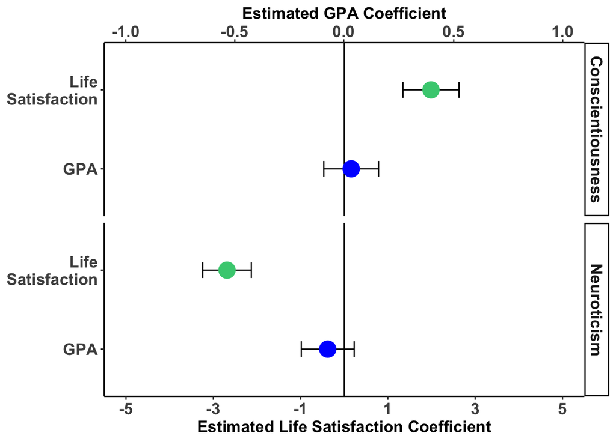

```r
tidy_mod_fun <- function(model){
  tidy(model) %>%
    bind_cols(tbl_df(confint(model, method = "boot")))
}

trait_fits <- w1_composites %>%
  left_join(select(target.ratings, SID, wave, GPA, procrastinate, life_sat)) %>%
  ungroup() %>%
  gather(key = outcome, value = value, GPA:life_sat) %>%
  gather(key = trait, value = value2, ESM_Agreeableness:ESM_Neuroticism) %>%
  group_by(wave, outcome, trait) %>%
  nest() %>%
  mutate(model = map(data, possibly(~lm(value ~ value2, data = .), NA_real_)),
         tidy = map(model, possibly(tidy_mod_fun, NA_real_)))

trait.dat <- trait_fits %>%
  filter(!is.na(model) & wave == "1" & outcome != "procrastinate" ) %>%
  unnest(tidy, .drop = T) %>%
  filter(term != "(Intercept)") %>%
  mutate(trait = mapvalues(trait, unique(trait),
                c("Extraversion", "Agreeableness","Conscientiousness", "Neuroticism")),
         outcome = recode(outcome, `life_sat` = "Life\nSatisfaction"),
         outcome = factor(outcome, levels = rev(unique(outcome)))) %>%
  filter(trait %in% c("Conscientiousness", "Neuroticism"))

trait.dat %>%
  ggplot(aes(x = outcome, y = estimate)) +
    scale_color_manual(values = c("blue", "seagreen3")) +
    geom_errorbar(data = filter(trait.dat, outcome == "GPA"), width = .2,
                  aes(ymin = `2.5 %`*5, ymax = `97.5 %`*5), position = "dodge") +
    geom_errorbar(data = filter(trait.dat, outcome == "Life\nSatisfaction"),
                  aes(ymin = `2.5 %`, ymax = `97.5 %`), width = .2, position = "dodge") +
    geom_hline(yintercept = 0) +
    geom_point(data = filter(trait.dat, outcome == "GPA"),
               aes(y = estimate*5, color = outcome), size = 6) +
  geom_point(data = filter(trait.dat, outcome == "Life\nSatisfaction"),
             aes(y = estimate, color = outcome), size = 6) +
    scale_y_continuous(limits = c(-5,5), breaks = seq(-5,5,2),
                     sec.axis = sec_axis(~./5, name = "Estimated GPA Coefficient")) +
    labs(y = "Estimated Life Satisfaction Coefficient", x = NULL) +
    coord_flip() +
    facet_grid(trait~.) +
    theme_classic() +
    theme(legend.position = "none",
          axis.text = element_text(face = "bold", size = rel(1.2)),
          axis.title = element_text(face = "bold", size = rel(1.2)),
          strip.text = element_text(face = "bold", size = rel(1.2)))
```

```r
ggsave(file = "~/Box Sync/network/PAIRS/outcomes/graphs/trait_bs2.png", width = 5, height = 5)
```

# 4 Question1: Do Idiographic Predictive Networks Predict Outcomes

```r
gVAR_fun <- function(x, outcome = NULL, SID, wave){
  print(sprintf("Wave %s: S%s", wave, SID))
  colnum <- which(colnames(x) %in% outcome)
  n <- dim(x)[1]
  x <- x %>%
    arrange(beepvar3) %>%
    select(A_rude:N_worried, colnum)
  gamma <- 0
  lambda <- seq(.1, .25, .025)
  fit <-
    graphicalVAR(x, gamma = gamma, maxit.in = 1000, maxit.out = 1000,
                      lambda_beta = lambda, lambda_kappa = lambda,
                      verbose = T, scale = F, centerWithin = F)
  return(fit)
}

gVAR_fit <- w1_test %>%
  select(-contains("sd")) %>%
  full_join(select(w2_test, -contains("sd"))) %>%
  filter(!(SID %in% c("10516", "10204", "10322"))) %>% #program bug, these freeze R
  group_by(SID, wave, count) %>%
  nest()

gVAR_fit <- gVAR_fit %>%
  mutate(gVAR_fit0 = pmap(list(x = data, SID = SID, wave = wave), possibly(gVAR_fun, NA_real_)))
save(gVAR_fit, file = "~/Box Sync/network/PAIRS/outcomes/gVAR_fit.RData")
```

## 4.1 Extract Results and Save Into Data Frames

Now that we’ve fitted the regularized networks, we need to extract the edge weights of the models to estimate network properties. For each person, we pull out the coefficients and save them into long-format data frames and merge them together.

```r
beta_fun <- function(fit, SID){
  PDC <- fit$PDC
  from <- row.names(PDC)
  nvar <- length(from)
  PDC.long <- tbl_df(PDC) %>%
    mutate(from = from,
           type = "Temporal") %>%
    gather(key = to, value = value, 1:nvar) %>%
    mutate(sign = ifelse(value < 0, -1, ifelse(value > 0, 1, 0))) %>%
    unite(var, from, to, sep = ".", remove = F)
}

kappa_mat_fun <- function(fit){fit$PCC}

kappa_long_fun <- function(fit){
  PCC <- fit$PCC
  PCC <- PCC[,order(colnames(PCC))]
  PCC <- PCC[order(rownames(PCC)),]
  PCC[lower.tri(PCC, diag = T)] <- NA
  vars <- rownames(PCC)
  nvar <- length(vars)
  PCC.long <- tbl_df(PCC) %>%
    mutate(Var1 = vars,
           type = "Contemporaneous") %>%
    gather(key = Var2, value = value, 1:nvar) %>%
    filter(!is.na(value)) %>%
    mutate(sign = ifelse(value < 0, -1, 1)) %>%
    unite(var, Var1, Var2, sep = ".", remove = F)
}

gVAR_fit <- gVAR_fit %>%
  filter(!is.na(gVAR_fit0)) %>%
  mutate(beta0 = map2(gVAR_fit0, SID, possibly(beta_fun, NA_real_)),
         kappa_mat0 = map(gVAR_fit0, possibly(kappa_mat_fun, NA_real_)),
         kappa0 = map(gVAR_fit0, possibly(kappa_long_fun, NA_real_)))

beta_long0 <- gVAR_fit %>% filter(!is.na(beta0)) %>% unnest(beta0)
kappa_long0 <- gVAR_fit %>% filter(!is.na(kappa0)) %>% unnest(kappa0)

# save fit information
beta_long0$fit <- "personality"
kappa_long0$fit <- "personality"

#get variable names from models
varnames_fit0 <- row.names(gVAR_fit$gVAR_fit0[[1]]$beta)
# extract PCC information
PCC_fit0 <- gVAR_fit$kappa_mat0; names(PCC_fit0) <- gVAR_fit$SID
```

## 4.2 Plots

Next, we plot the networks using the Fruchterman-Reingold algorithm, a force-directed algorithm that arranges the regularized partial temporal and contemporaneous correlations spatially to allow for interpretation.

```r
edge_colors <- RColorBrewer::brewer.pal(8, "Purples")[c(3,4,6)]

plot_fun <- function(data, subject, wave, type){
  if(type == "Temporal"){data_mod <- data$PDC}
  else{data_mod <- data$PCC}
  groups <- list(A = c(1,7), E = c(2, 6), C = c(3,8), N = c(4,5,9))
  plot <- qgraph(data_mod, layout = "spring", title = sprintf("%s Wave %s for S%s", type, wave, subject),
                   loop = .7, node.width = 1.4, edge.width = 1, label.font = 2,
                   label.fill.vertical = 1, label.fill.horizontal = 1, edge.color = "black",
                   groups = groups, color = RColorBrewer::brewer.pal(8, "Set3")[1:5],
                   legend = T, DoNotPlot = TRUE, mar = c(4,4,4,4))
  #change lines to dashed
  plot$graphAttributes$Edges$lty[plot$Edgelist$weight < 0] <- 2
  #change line colors
  plot$graphAttributes$Edges$color <-
    ifelse(abs(plot$Edgelist$weight) <.1, edge_colors[1],
    ifelse(abs(plot$Edgelist$weight) <.3, edge_colors[2], edge_colors[3]))
  #change variable names
  plot$graphAttributes$Nodes$labels <- varnames2
  return(plot)
}

gVAR_fit <- gVAR_fit %>%
  mutate(temp_plot = pmap(list(gVAR_fit0, SID, wave, "Temporal"), possibly(plot_fun, NA_real_)),
         contemp_plot = pmap(list(gVAR_fit0, SID, wave, "Contemporaneous"), possibly(plot_fun, NA_real_)))
```

## 4.3 Split Half Networks (Reliability Check)

To test the reliability of the networks, we split each person’s responses in half and calculate a network of eah and then compare the two using profile correlations.

```r
gVAR_fit_split <- w1_test %>%
  select(-contains("sd")) %>%
  full_join(select(w2_test, -contains("sd"))) %>% ungroup() %>%
  mutate(split = ifelse(count %% 2 == 0, count/2, count%/%2),
         split = ifelse(beepvar3 <= split, 1, 2)) %>%
  # the following subjects freeze R because the sample size is too small when split,
  # so we remove them.
  filter(!((wave == "1" & SID %in% c("68", "10148", "10160", "10455", "10187",
                            "10273","10428", "10259", "10304", "10345", "10512")) |
                (wave == "2" & SID %in% c("12", "87", "102", "10248", "10280",
                                           "10287", "10444")))) %>%
  group_by(SID, wave, count, split) %>%
  nest()

gVAR_fit_split <- gVAR_fit_split %>%
  mutate(gVAR_fit0 = pmap(list(x = data, SID = SID, wave = wave), possibly(gVAR_fun, NA_real_)))
save(gVAR_fit, gVAR_fit_split, file = "~/Box Sync/network/PAIRS/outcomes/gVAR_fit.RData")
```

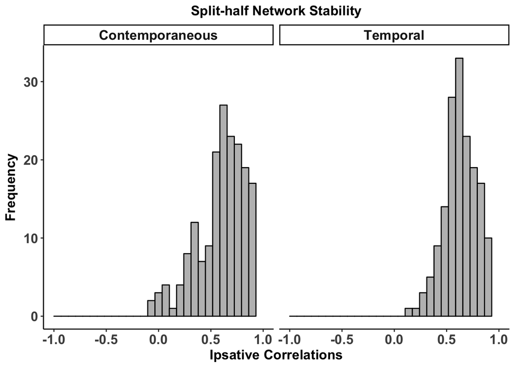

```r
gVAR_fit_split <- gVAR_fit_split %>%
  filter(!is.na(gVAR_fit0)) %>%
  group_by(SID, wave) %>%
  mutate(n = n()) %>%
  # we can only assess individuals for whom we could estimate a network for each
  # half of their data within a wave
  filter(n == 2) %>%
  mutate(beta0 = map2(gVAR_fit0, SID, possibly(beta_fun, NA_real_)),
         kappa_mat0 = map(gVAR_fit0, possibly(kappa_mat_fun, NA_real_)),
         kappa0 = map(gVAR_fit0, possibly(kappa_long_fun, NA_real_)))

split_beta_long0 <- gVAR_fit_split %>% filter(!is.na(beta0)) %>% unnest(beta0)
split_kappa_long0 <- gVAR_fit_split %>% filter(!is.na(kappa0)) %>% unnest(kappa0)

#get variable names from models
varnames_fit0 <- row.names(gVAR_fit_split$gVAR_fit0[[1]]$beta)
# extract PCC information
split_PCC_fit0 <- gVAR_fit_split$kappa_mat0; names(split_PCC_fit0) <- gVAR_fit_split$SID

ip_split_cors <- split_beta_long0 %>%
  mutate(type = "PDC") %>%
  full_join(split_kappa_long0 %>%
              mutate(type = "PCC") %>%
              rename(from = Var1, to = Var2)) %>%
  group_by(SID, type, wave, split) %>%
  mutate(value.c = as.numeric(scale(value, center = T, scale = F))) %>%
  ungroup() %>%
  arrange(wave, type, split, SID, from, to) %>%
  select(-value) %>%
  spread(split, value.c) %>%
  group_by(SID, wave, type) %>%
  summarize(cors = cor(`1`, `2`, use = "pairwise.complete.obs"))

ip_split_cors %>%
  filter(wave == "1") %>%
  mutate(type = recode(type, `PDC` = "Temporal", `PCC` = "Contemporaneous")) %>%
  ggplot(aes(x = cors)) +
  geom_histogram(color = "black", fill = "gray") +
  scale_x_continuous(limits = c(-1,1), breaks = seq(-1,1,.5)) +
  labs(x = "Ipsative Correlations", y = "Frequency",
       title = "Split-half Network Stability") +
  facet_grid(.~type) +
  theme_classic() +
  theme(axis.text = element_text(face = "bold", size = rel(1.2)),
        axis.title = element_text(face = "bold", size = rel(1.2)),
        strip.text = element_text(face = "bold", size = rel(1.2)),
        plot.title = element_text(face = "bold", size = rel(1.2), hjust = .5))
```

```r
ggsave(file = "~/Box Sync/network/PAIRS/outcomes/graphs/split_half_ipsative.png", width = 6, height = 3)
```

## 4.4 Cross-Wave Stability (Reliability Check #2)

Given concerns about the replicability of networks, we not only test network stability within waves, we also test network stablity across waves.

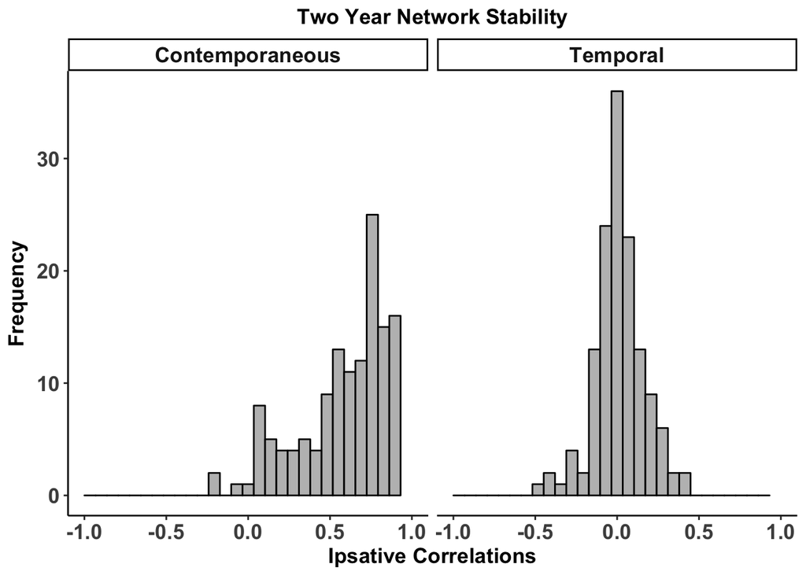

```r
ip_cors <- beta_long0 %>%
  mutate(type = "PDC") %>%
  full_join(kappa_long0 %>%
              mutate(type = "PCC") %>%
              rename(from = Var1, to = Var2)) %>%
  filter(fit == "personality") %>%
  group_by(SID, type, wave) %>%
  mutate(weight.c = as.numeric(scale(value, center = T, scale = F))) %>%
  ungroup() %>%
  arrange(wave, SID, from, to) %>%
  select(-sign, -value, -count) %>%
  spread(wave, weight.c) %>%
  group_by(SID, type) %>%
  summarize(cors = cor(`1`, `2`, use = "pairwise.complete.obs")) %>%
  filter(!is.na(cors))


ip_cors %>%
  mutate(type = recode(type, `PDC` = "Temporal", `PCC` = "Contemporaneous")) %>%
  ggplot(aes(x = cors)) +
  geom_histogram(color = "black", fill = "gray") +
  scale_x_continuous(limits = c(-1,1), breaks = seq(-1,1,.5)) +
  labs(x = "Ipsative Correlations", y = "Frequency",
       title = "Two Year Network Stability") +
  facet_grid(.~type) +
  theme_classic() +
  theme(axis.text = element_text(face = "bold", size = rel(1.2)),
        axis.title = element_text(face = "bold", size = rel(1.2)),
        strip.text = element_text(face = "bold", size = rel(1.2)),
        plot.title = element_text(face = "bold", size = rel(1.2), hjust = .5))
```

```r
ggsave(file = "~/Box Sync/network/PAIRS/outcomes/graphs/ipsative.png", width = 6, height = 3)
```

## 4.5 Regressions

Now that we have our edge weights in nice data frames, pretty plots of the networks, and have tested their stability over time, let’s test how they relate to different outcomes. First we test how single edge weights across people are related to outcomes of interest – GPA, life satisfaction, and procrastinations (procrastination omitted in presentation.)

```r
beta <- tbl_df(beta_long0) %>%
  left_join(select(target.ratings, SID, wave,
                   GPA, procrastinate, life_sat)) %>%
  left_join(w1_composites) %>%
  filter(!is.na(value))

beta_long <- beta %>%
  select(SID:fit, GPA, procrastinate, life_sat, ESM_Conscientiousness, ESM_Neuroticism) %>%
  gather(key = outcome, value = value2, GPA:life_sat) %>%
  mutate(Edge_Trait1 = ifelse(grepl("C_",from) == T, "C",
                       ifelse(grepl("N_", from) == T, "N", NA)),
         Edge_Trait2 = ifelse(grepl("C_",to) == T, "C",
                       ifelse(grepl("N_", to) == T, "N", NA))) %>%
  filter((Edge_Trait1 == "C" & Edge_Trait2 == "C") |
         (Edge_Trait1 == "N" & Edge_Trait2 == "N") |
         (Edge_Trait1 == "C" & Edge_Trait2 == "N") |
         (Edge_Trait1 == "N" & Edge_Trait2 == "C"))

PDC_model <- function(df){
    mod1 <- lm(value2 ~ value, data = df)
    modT <- lm(value2 ~ value + ESM_Conscientiousness + ESM_Neuroticism, data = df)
    results <- list(mod1, modT)
    return(results)
}

PDC_tidy <- function(mod_list){
  tidy_mod1 <- tidy(mod_list[[1]]) %>% mutate(covar = "EW") %>%
    bind_cols(tbl_df(confint(mod_list[[1]], method = "boot")))
  tidy_modT <- tidy(mod_list[[2]]) %>% mutate(covar = "C+N") %>%
    bind_cols(tbl_df(confint(mod_list[[2]], method = "boot")))
  tidy_mods <- tidy_mod1 %>%
    full_join(tidy_modT)
  return(tidy_mods)
}

PDC_fits <- beta_long %>%
  group_by(outcome, wave, fit, var) %>%
  nest() %>%
  mutate(model = map(data, possibly(PDC_model, NA_real_)),
         tidy = map(model, possibly(PDC_tidy, NA_real_)))
```

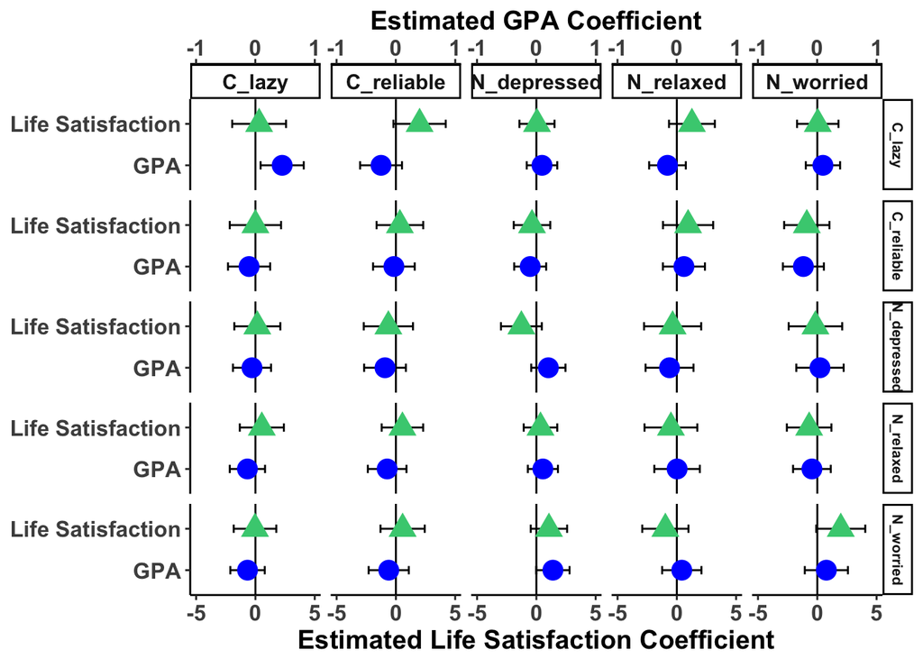

```r
PDC.dat <- PDC_fits %>%
  filter(!is.na(tidy)) %>%
  unnest(tidy) %>%
  filter(fit == "personality" & term == "value" & covar == "EW" & outcome != "procrastinate") %>%
  separate(var, into = c("from", "to"), sep = "[.]") %>%
  mutate(outcome = recode(outcome, `life_sat` = "Life Satisfaction")) %>%
  unite(comb, outcome, wave, sep = ": ", remove = F) %>%
  mutate(comb = factor(comb, levels = rev(unique(comb))),
         outcome = factor(outcome, levels = rev(unique(outcome))))

PDC.dat %>%
  ggplot(aes(x = outcome, y = estimate)) +
    geom_errorbar(data = filter(PDC.dat, outcome == "GPA"), width = .2,
                  aes(ymin = `2.5 %`*5, ymax = `97.5 %`*5), position = "dodge") +
    geom_errorbar(data = filter(PDC.dat, outcome != "GPA"),
                  aes(ymin = `2.5 %`, ymax = `97.5 %`), position = "dodge", width = .2) +
    geom_hline(aes(yintercept = 0)) +
    geom_point(data = filter(PDC.dat, outcome == "GPA"),
               aes(y = estimate * 5, color = outcome, shape = outcome), size = 5) +
    geom_point(data = filter(PDC.dat, outcome != "GPA"),
               aes(color = outcome, shape = outcome), size = 5) +
    scale_color_manual(values = c("blue", "seagreen3")) +
    scale_y_continuous(limits = c(-5,5), breaks = seq(-5, 5, 5),
                       sec.axis = sec_axis(~./5, name = "Estimated GPA Coefficient",
                                           breaks = seq(-1,1,1))) +
    #scale_color_manual(values = c("red", "blue", "green")) +
    labs(y = "Estimated Life Satisfaction Coefficient", x = NULL) +
    coord_flip() +
    facet_grid(from~to) +
    theme_classic() +
    theme(legend.position = "none",
          axis.text = element_text(face = "bold", size = rel(1.1)),
          axis.title = element_text(face = "bold", size = rel(1.3)),
          strip.text.x = element_text(face = "bold", size = rel(1.3)),
          strip.text.y = element_text(face = "bold", size = rel(.9)))
```

```r
ggsave(file = "~/Box Sync/network/PAIRS/outcomes/graphs/temp_ew_bs2.png", width = 8, height = 5)
```

### 4.5.1 Contemporaneous

```r
PCC <- tbl_df(kappa_long0) %>%
  left_join(select(target.ratings, SID, wave, GPA, procrastinate, life_sat)) %>%
  left_join(w1_composites) %>%
  filter(!is.na(value))

PCC_long <- PCC %>%
  select(SID:fit, GPA, procrastinate, life_sat, ESM_Conscientiousness, ESM_Neuroticism) %>%
  gather(key = outcome, value = value2, GPA:life_sat) %>%
   mutate(Edge_Trait1 = ifelse(grepl("C_",Var1) == T, "C",
                        ifelse(grepl("N_", Var1) == T, "N", NA)),
         Edge_Trait2 = ifelse(grepl("C_",Var2) == T, "C",
                       ifelse(grepl("N_", Var2) == T, "N", NA))) %>%
  filter((Edge_Trait1 == "C" & Edge_Trait2 == "C") |
         (Edge_Trait1 == "N" & Edge_Trait2 == "N") |
         (Edge_Trait1 == "C" & Edge_Trait2 == "N") |
         (Edge_Trait1 == "N" & Edge_Trait2 == "C"))

PCC_fits <- PCC_long %>%
  group_by(outcome, wave, fit, var) %>%
  nest() %>%
  mutate(model = map(data, possibly(PDC_model, NA_real_)),
         tidy = map(model, possibly(PDC_tidy, NA_real_)))
```

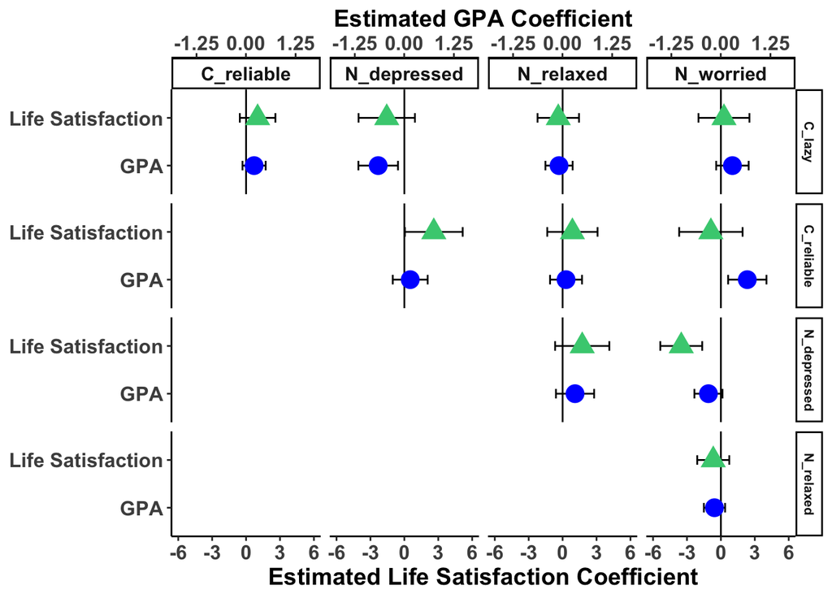

```r
PCC.dat <- PCC_fits %>%
  filter(!is.na(tidy)) %>%
  unnest(tidy) %>%
  filter(fit == "personality" & term == "value" & covar == "EW" &
           outcome != "procrastinate" & wave == "1") %>%
  separate(var, into = c("from", "to"), sep = "[.]") %>%
  mutate(outcome = recode(outcome, `life_sat` = "Life Satisfaction")) %>%
  unite(comb, outcome, wave, sep = ": ", remove = F) %>%
  mutate(comb = factor(comb, levels = rev(unique(comb))),
         outcome = factor(outcome, levels = rev(unique(outcome))))

PCC.dat %>%
  ggplot(aes(x = outcome, y = estimate)) +
    geom_errorbar(data = filter(PCC.dat, outcome == "GPA"), width = .2,
                  aes(ymin = `2.5 %`*3.5, ymax = `97.5 %`*3.5), position = "dodge") +
    geom_errorbar(data = filter(PCC.dat, outcome != "GPA"),
                  aes(ymin = `2.5 %`, ymax = `97.5 %`), position = "dodge", width = .2) +
    geom_hline(aes(yintercept = 0)) +
    geom_point(data = filter(PCC.dat, outcome == "GPA"),
               aes(y = estimate * 3.5, color = outcome, shape = outcome), size = 5) +
    geom_point(data = filter(PCC.dat, outcome != "GPA"),
               aes(color = outcome, shape = outcome), size = 5) +
    scale_y_continuous(limits = c(-6,6), breaks = seq(-6, 6, 3),
                       sec.axis = sec_axis(~./3.5, name = "Estimated GPA Coefficient",
                                           breaks = seq(-1.25,1.25,1.25))) +
    scale_color_manual(values = c("blue", "seagreen3")) +
    labs(y = "Estimated Life Satisfaction Coefficient", x = NULL) +
    coord_flip() +
    facet_grid(from~to) +
    theme_classic() +
    theme(legend.position = "none",
          axis.text = element_text(face = "bold", size = rel(1.1)),
          axis.title = element_text(face = "bold", size = rel(1.3)),
          strip.text.x = element_text(face = "bold", size = rel(1.3)),
          strip.text.y = element_text(face = "bold", size = rel(.9)))
```

```r
ggsave(file = "~/Box Sync/network/PAIRS/outcomes/graphs/contemp_ew_bs2.png", width = 8, height = 5)
```

# 5 Question 2: Does centrality relate to outcomes?

## 5.1 Run Ideographic Centrality Analyses

Centrality is a measure of the relative importance of nodes within a network. Typically, this is considered at the person level, telling us how different nodes stack up to each other. We take a slightly different approach, asking the question of how the number of connections any given node has relative to *other* people is related to life outcomes. So first, we calculate various centrality measures (we focus on the first and simplest – degree centrality – in the presentation). Notably, some types of centrality vary both in usefulness, type, and interpretation between temporal and contemporaneous networks. In temporal networks, we might be interested in whether some behaviors are affected or affectors – do some nodes influence other nodes more than other nodes influence it. In these cases, we calculate two indicators of a type of centrality, such as in degree and out degree, which tells you about the direction of influence in connectivity of the nodes.

Once we calculate centrality, we extract the values into a nice data frame and merge them across participants.

```r
# create function to save both centrality measure and variable names to a data frame.
centralityList <- function(x, type, gVAR) {
  if(type == "temporal"){
      centrality <- centrality_auto(data.frame(select(x, from, to, value)))
      mat <- gVAR$PDC
      diag(mat) <- 0
      varnames <- as.character(unique(x$from))
      degree <- tibble(var = row.names(mat),
                       InDegree = colSums(mat != 0),
                       OutDegree = rowSums(mat != 0))}
    else{
      centrality <- centrality_auto(x)
      mat <- gVAR$PCC
      diag(mat) <- 0
      degree <- tibble(var = rownames(x),
                       Degree = colSums(mat != 0))
      varnames <- rownames(x)}
    df <- tbl_df(centrality$node.centrality %>% mutate(var = varnames)) %>%
      full_join(degree)
  return(df)
}
```

```r
gVAR_fit <- gVAR_fit %>%
  mutate(beta_centrality0 = map2(beta0, gVAR_fit0, possibly(~centralityList(.x,
                                       "temporal", .y), NA_real_)),
         kappa_centrality0 = map2(kappa_mat0, gVAR_fit0, possibly(~centralityList(.x,
                                       "contemporaneous", .y), NA_real_)))
```

```r
# let's reshape and merge the results within models
centrality_fit0_PDC_long <- gVAR_fit %>%
  filter(!is.na(beta_centrality0)) %>%
  unnest(beta_centrality0, .drop = T) %>%
  mutate(fit = "personality", type = "Temporal")

centrality_fit0_PCC_long <- gVAR_fit %>%
  filter(!is.na(kappa_centrality0)) %>%
  unnest(kappa_centrality0, .drop = T) %>%
  mutate(fit = "personality", type = "Contemporaneous")

# let's reshape and merge the results across models
centrality <- centrality_fit0_PDC_long %>%
  full_join(centrality_fit0_PCC_long) %>%
  gather(key = measure, value = value, Betweenness:OutStrength,
         Strength, InDegree, OutDegree, Degree) %>%
  filter(!is.na(value)) %>%
  group_by(fit, wave, type, SID, measure) %>%
  mutate(z = as.numeric(scale(value))) %>%
  ungroup()

# all the centrality ratings with rankings + outcomes
centrality5 <- centrality %>%
  left_join(target.ratings) %>%
  left_join(w1_composites) %>%
  filter(!is.na(fit)) %>%
  mutate()
```

## 5.2 Regressions

Now that we have our centrality indices, we can estimate the regression models using centrality as the predictor and GPA, life satisfaction, and procrastination.

```r
centrality_model <- function(df){
    mod1 <- lm(value2 ~ value, data = df)
    modT <- lm(value2 ~ value + ESM_Conscientiousness + ESM_Neuroticism, data = df)
    results <- list(mod1, modT)
    return(results)
}

centrality_long <- centrality5 %>%
  select(SID:measure, value, z, GPA, procrastinate, life_sat,
         ESM_Neuroticism, ESM_Conscientiousness) %>%
  gather(key = outcome, value = value2, GPA:life_sat) %>%
  mutate(Edge_Trait1 = ifelse(grepl("C_",var) == T, "C",
                       ifelse(grepl("N_", var) == T, "N", NA))) %>%
  filter(Edge_Trait1 == "C" | Edge_Trait1 == "N") %>%
  mutate(model_type = ifelse(outcome == "rel_stat", "glm", "lm"))

centrality_fits <- centrality_long %>%
  group_by(outcome, wave, fit, var, measure, type) %>%
  nest() %>%
  mutate(model = map(data, possibly(centrality_model, NA_real_)),
         tidy = map(model, possibly(PDC_tidy, NA_real_))) %>%
  filter(!is.na(model))
```

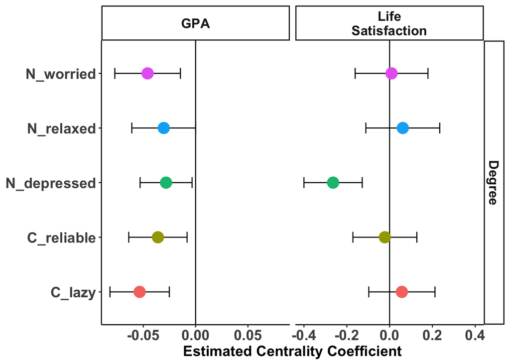

```r
centrality_fits %>%
  filter(!is.na(tidy)) %>%
  unnest(tidy) %>%
  filter(fit == "personality" & (measure %in% c("Degree", "InDegree", "OutDegree")) &
           term == "value" & covar == "EW" & type == "Contemporaneous" & wave == "1" &
           !(outcome %in% c("sr_health", "procrastinate"))) %>%
  mutate(outcome = recode(outcome, `sr_health` = "Self-Rated\nHealth",
                         `friendship_sat` = "Friendship\nSatisfaction",
                         `life_sat` = "Life\nSatisfaction")) %>%
  group_by(wave, outcome) %>%
  mutate(ymin = min(`2.5 %`, na.rm = T),
         ymax = max(`97.5 %`, na.rm = T),
         ymin2 = ifelse(abs(ymin) > abs(ymax), ymin, -1*ymax),
         ymax2 = ifelse(abs(ymax) > abs(ymin), ymax, -1*ymin)) %>%
  unite(comb, measure, wave, sep = ": ", remove = F) %>%
  ggplot(aes(x = var, y = estimate)) +
    geom_errorbar(aes(ymin = `2.5 %`, ymax = `97.5 %`), width = .2, position = "dodge") +
    geom_hline(aes(yintercept = 0)) +
    geom_point(aes(color = var), size = 5) +
    geom_blank(aes(y = ymin2)) + geom_blank(aes(y = ymax2)) +
    labs(y = "Estimated Centrality Coefficient", x = NULL) +
    coord_flip() +
    facet_grid(measure~outcome, scales = "free") +
    theme_classic() +
    theme(legend.position = "none",
          axis.text = element_text(face = "bold", size = rel(1.3)),
          axis.title = element_text(face = "bold", size = rel(1.3)),
          strip.text = element_text(face = "bold", size = rel(1.2)))
```

```r
ggsave(file = "~/Box Sync/network/PAIRS/outcomes/graphs/contemp_cent_bs.png", width = 6, height = 6)
```

# 6 Question 3: Does density predict outcomes

Because density is global property, we only calculate one regression for each outcome for temporal and contemporaneous networks.

```r
density_fun <- function(edgelist, type){
  if (type == "Temporal"){
    nvar <- length(unique(c(edgelist$from, edgelist$to)))
    pc <- nvar^2
  } else {
    nvar <- length(unique(c(edgelist$Var1, edgelist$Var2)))
    pc <- (nvar * (nvar - 1)) / 2
  }
  density <- sum(edgelist$value != 0) / pc
}

gVAR_fit <- gVAR_fit %>%
  mutate(temp_density0 = map_dbl(beta0, possibly(~density_fun(., "Temporal"), NA_real_)),
         contemp_density0 = map_dbl(kappa0, possibly(~density_fun(., "Contemporaneous"), NA_real_)))

density <- gVAR_fit %>%
  select(SID, wave, contains("density")) %>%
  gather(key = type, value = density, temp_density0:contemp_density0) %>%
  separate(type, into = c("type", "fit")) %>%
  mutate(type = recode(type, `temp` = "Temporal", `contemp` = "Contemporaneous"))
```

## 6.1 Regressions

```r
mod_density <- function(data){lm(value ~ density , data = data)}

tidy_density <- function(model){
  tidy(model) %>%
    bind_cols(tbl_df(confint(model, method = "boot")))
}

density_fits <- density %>%
  left_join(target.ratings) %>%
  left_join(w1_composites) %>%
  select(SID, wave, density, type, fit, GPA, procrastinate, life_sat, ESM_Neuroticism, ESM_Conscientiousness) %>%
  gather(key = outcome, value = value, GPA:life_sat) %>%
  group_by(type, wave, fit, outcome) %>%
  nest() %>%
  mutate(model = map(data, possibly(mod_density, NA_real_)),
         tidy = map(model, possibly(tidy_density, NA_real_)))

density_fits.df <- density_fits %>%
  filter(!is.na(tidy)) %>%
  unnest(tidy, .drop = T) %>%
  select(-std.error, -statistic) %>%
  gather(key = term2, value = value, estimate, p.value) %>%
  unite(comb, outcome, term2) %>%
  spread(key = comb, value = value)
```

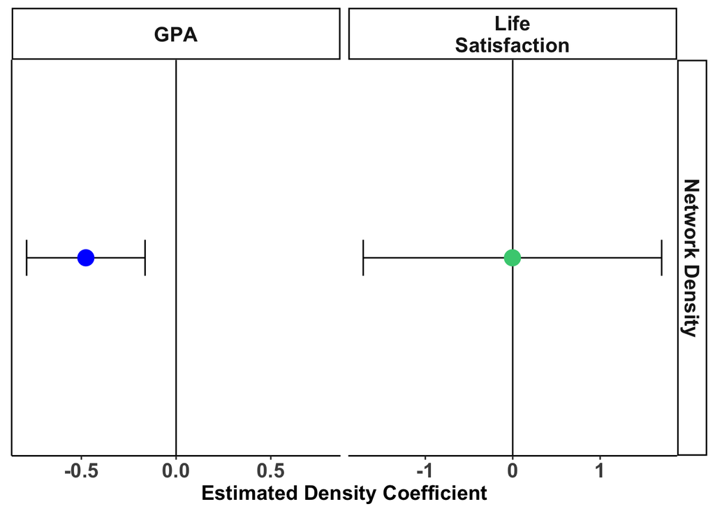

```r
density_fits %>%
  filter(!is.na(tidy)) %>%
  unnest(tidy, .drop = T) %>%
  filter(term == "density" & type == "Contemporaneous" & wave == "1" & fit == "density0" &
           !(outcome %in% c("sr_health", "procrastinate"))) %>%
  mutate(outcome = recode(outcome, `sr_health` = "Self-Rated Health",
                          `friendship_sat` = "Friendship Satisfaction",
                          `life_sat` = "Life\nSatisfaction"),
         measure = "Network Density") %>%
  unite(comb, outcome, wave, sep = ": ", remove = F) %>%
  group_by(wave, outcome) %>%
  mutate(ymin = min(`2.5 %`, na.rm = T),
         ymax = max(`97.5 %`, na.rm = T),
         ymin2 = ifelse(abs(ymin) > abs(ymax), ymin, -1*ymax),
         ymax2 = ifelse(abs(ymax) > abs(ymin), ymax, -1*ymin)) %>%
  ggplot(aes(x = 1, y = estimate)) +
    geom_errorbar(aes(ymin = `2.5 %`, ymax = `97.5 %`), width = .2, position = "dodge") +
    geom_hline(aes(yintercept = 0)) +
    geom_point(aes(color = outcome), size = 5) +
    scale_x_continuous(limits = c(0,2)) +
    geom_blank(aes(y = ymin2)) + geom_blank(aes(y = ymax2)) +
    scale_color_manual(values = c("blue", "seagreen3")) +
    #scale_y_continuous(limits = c(-1, 1), breaks = seq(-1, 1,.5)) +
    labs(y = "Estimated Density Coefficient", x = NULL) +
    coord_flip() +
    facet_grid(measure~outcome, scales = "free") +
    theme_classic() +
    theme(legend.position = "none",
          axis.text = element_text(face = "bold", size = rel(1.3)),
          axis.title = element_text(face = "bold", size = rel(1.3)),
          strip.text = element_text(face = "bold", size = rel(1.3)),
          axis.text.y = element_blank(),
          axis.ticks.y = element_blank())
```

```r
ggsave(file = "~/Box Sync/network/PAIRS/outcomes/graphs/contemp_density_bs.png", width = 5, height = 5)
```